# 560 Lecture 2 - Descriptive Statistics and Graphs

Douglas M. Fowler

3/25/2017

## Load some data, get basic summaries

#### Read the results of the WW domain deep mutational scan in

```r
ww_data = read.table(file="http://faculty.washington.edu/dfowler/teaching/2017/GNOM560/560_ww_data.txt", header = T, sep = '\t')
```

#### Get some information about the data frame using the str(), head() and names() functions

```r
str(ww_data)
```

```
## 'data.frame':    377 obs. of  24 variables:
##  $ position_id    : Factor w/ 34 levels "Yap65_170","Yap65_171",..: 33 25 24 21 20 19 18 11 8 7 ...
##  $ variant_id     : Factor w/ 377 levels "WW_domain_A175C",..: 210 45 123 160 86 377 266 17 370 96 ...
##  $ dms_id         : Factor w/ 1 level "WW_domain": 1 1 1 1 1 1 1 1 1 1 ...
##  $ organism       : Factor w/ 1 level "H. sapiens": NA NA NA NA NA NA NA NA NA NA ...
##  $ uniprot_id     : Factor w/ 1 level "P46937": 1 1 1 1 1 1 1 1 1 1 ...
##  $ reported_effect: num  -0.486 0.122 -0.031 0.07 0.398 -0.037 0.248 -0.259 -0.25 0.217 ...
##  $ scaled_effect  : num  0.898 1.021 0.99 1.01 1.076 ...
##  $ aa1            : Factor w/ 19 levels "A","D","E","F",..: 12 2 7 9 4 19 14 1 18 5 ...
##  $ aa2            : Factor w/ 21 levels "A","C","D","E",..: 13 3 8 10 5 21 15 1 19 6 ...
##  $ position       : int  202 194 193 190 189 188 187 180 177 176 ...
##  $ aa1_polarity   : Factor w/ 5 levels "Hydrophobic",..: 5 2 1 1 1 1 4 1 1 5 ...
##  $ aa2_polarity   : Factor w/ 6 levels "Hydrophobic",..: 5 2 1 1 1 1 4 1 1 5 ...
##  $ aa1_pi         : num  6.3 5.05 6.02 9.71 3.32 5.66 6.34 6 5.89 3.29 ...
##  $ aa2_pi         : num  6.3 5.05 6.02 9.71 3.32 5.66 6.34 6 5.89 3.29 ...
##  $ delta_pi       : num  0 0 0 0 0 0 0 0 0 0 ...
##  $ aa1_weight     : int  115 133 131 131 165 181 174 89 204 75 ...
##  $ aa2_weight     : num  115 133 131 131 165 181 174 89 204 75 ...
##  $ delta_weight   : num  0 0 0 0 0 0 0 0 0 0 ...
##  $ aa1_volume     : num  113 111 167 167 190 ...
##  $ aa2_volume     : num  113 111 167 167 190 ...
##  $ delta_volume   : num  0 0 0 0 0 0 0 0 0 0 ...
##  $ aa1_psic       : num  NA NA NA NA NA NA NA NA NA NA ...
##  $ aa2_psic       : num  NA NA NA NA NA NA NA NA NA NA ...
##  $ delta_psic     : num  NA NA NA NA NA NA NA NA NA NA ...
```

```r
head(ww_data)
```

```
##   position_id      variant_id    dms_id organism uniprot_id
## 1   Yap65_202 WW_domain_P202P WW_domain     <NA>     P46937
## 2   Yap65_194 WW_domain_D194D WW_domain     <NA>     P46937
## 3   Yap65_193 WW_domain_I193I WW_domain     <NA>     P46937
## 4   Yap65_190 WW_domain_L190L WW_domain     <NA>     P46937
## 5   Yap65_189 WW_domain_F189F WW_domain     <NA>     P46937
## 6   Yap65_188 WW_domain_Y188Y WW_domain     <NA>     P46937
##   reported_effect scaled_effect aa1 aa2 position   aa1_polarity
## 1          -0.486     0.8984706   P   P      202        Special
## 2           0.122     1.0205871   D   D      194 negativeCharge
## 3          -0.031     0.9898571   I   I      193    Hydrophobic
## 4           0.070     1.0101429   L   L      190    Hydrophobic
## 5           0.398     1.0760215   F   F      189    Hydrophobic
## 6          -0.037     0.9886520   Y   Y      188    Hydrophobic
##     aa2_polarity aa1_pi aa2_pi delta_pi aa1_weight aa2_weight delta_weight
## 1        Special   6.30   6.30        0        115        115            0
## 2 negativeCharge   5.05   5.05        0        133        133            0
## 3    Hydrophobic   6.02   6.02        0        131        131            0
## 4    Hydrophobic   9.71   9.71        0        131        131            0
## 5    Hydrophobic   3.32   3.32        0        165        165            0
## 6    Hydrophobic   5.66   5.66        0        181        181            0
##   aa1_volume aa2_volume delta_volume aa1_psic aa2_psic delta_psic
## 1      112.7      112.7            0       NA       NA         NA
## 2      111.1      111.1            0       NA       NA         NA
## 3      166.7      166.7            0       NA       NA         NA
## 4      166.7      166.7            0       NA       NA         NA
## 5      189.9      189.9            0       NA       NA         NA
## 6      193.6      193.6            0       NA       NA         NA
```

```r
names(ww_data)
```

```
##  [1] "position_id"     "variant_id"      "dms_id"
##  [4] "organism"        "uniprot_id"      "reported_effect"
##  [7] "scaled_effect"   "aa1"             "aa2"
## [10] "position"        "aa1_polarity"    "aa2_polarity"
## [13] "aa1_pi"          "aa2_pi"          "delta_pi"
## [16] "aa1_weight"      "aa2_weight"      "delta_weight"
## [19] "aa1_volume"      "aa2_volume"      "delta_volume"
## [22] "aa1_psic"        "aa2_psic"        "delta_psic"
```

## Descriptive Statistics

#### For a broad overview of expression for each feature in the data set we can use the summary() function

```r
summary(ww_data)
```

```
##     position_id            variant_id        dms_id          organism
##  Yap65_183: 19   WW_domain_A175C:  1   WW_domain:377   H. sapiens:367
##  Yap65_194: 19   WW_domain_A175D:  1                   NA's      : 10
##  Yap65_170: 17   WW_domain_A175E:  1
##  Yap65_187: 17   WW_domain_A175F:  1
##  Yap65_175: 16   WW_domain_A175G:  1
##  Yap65_186: 16   WW_domain_A175H:  1
##  (Other)  :273   (Other)        :371
##   uniprot_id  reported_effect   scaled_effect           aa1
##  P46937:377   Min.   :-5.3317   Min.   :-0.07478   D      : 49
##               1st Qu.:-1.5887   1st Qu.: 0.67698   Q      : 40
##               Median :-0.4486   Median : 0.90599   T      : 37
##               Mean   :-0.8239   Mean   : 0.83059   S      : 34
##               3rd Qu.: 0.1361   3rd Qu.: 1.02343   P      : 27
##               Max.   : 1.7917   Max.   : 1.35594   A      : 25
##                                                    (Other):165
##       aa2         position             aa1_polarity         aa2_polarity
##  R      : 27   Min.   :170.0   Hydrophobic   :108   Hydrophobic   :140
##  S      : 25   1st Qu.:177.0   negativeCharge: 59   negativeCharge: 30
##  H      : 24   Median :185.0   Polar         :119   Polar         : 80
##  A      : 23   Mean   :185.3   PositiveCharge: 42   PositiveCharge: 65
##  P      : 23   3rd Qu.:194.0   Special       : 49   Special       : 58
##  T      : 22   Max.   :203.0                        Stop          :  4
##  (Other):233
##      aa1_pi          aa2_pi        delta_pi          aa1_weight
##  Min.   :3.220   Min.   :3.22   Min.   :-6.52000   Min.   : 75.0
##  1st Qu.:5.470   1st Qu.:5.47   1st Qu.:-0.70000   1st Qu.:115.0
##  Median :5.740   Median :5.74   Median : 0.01000   Median :131.0
##  Mean   :5.895   Mean   :5.93   Mean   : 0.03456   Mean   :129.2
##  3rd Qu.:6.240   3rd Qu.:6.30   3rd Qu.: 0.95000   3rd Qu.:146.0
##  Max.   :9.740   Max.   :9.74   Max.   : 6.52000   Max.   :204.0
##
##    aa2_weight   delta_weight        aa1_volume      aa2_volume
##  Min.   : 75   Min.   :-129.000   Min.   : 60.1   Min.   : 60.1
##  1st Qu.:117   1st Qu.: -18.000   1st Qu.:111.1   1st Qu.:111.1
##  Median :132   Median :   3.000   Median :116.1   Median :140.0
##  Mean   :134   Mean   :   4.894   Mean   :129.3   Mean   :137.6
##  3rd Qu.:155   3rd Qu.:  30.000   3rd Qu.:162.9   3rd Qu.:166.7
##  Max.   :204   Max.   : 129.000   Max.   :227.8   Max.   :227.8
##
##   delta_volume         aa1_psic         aa2_psic        delta_psic
##  Min.   :-167.700   Min.   :-1.993   Min.   :-4.760   Min.   :0.649
##  1st Qu.: -27.100   1st Qu.:-1.599   1st Qu.:-3.916   1st Qu.:1.796
##  Median :   4.800   Median :-1.402   Median :-3.495   Median :2.132
##  Mean   :   8.295   Mean   :-1.445   Mean   :-3.582   Mean   :2.136
##  3rd Qu.:  49.800   3rd Qu.:-1.235   3rd Qu.:-3.306   3rd Qu.:2.593
##  Max.   : 167.700   Max.   :-0.861   Max.   :-2.018   Max.   :3.441
##                     NA's   :11       NA's   :14       NA's   :14
```

#### Lets extract the data for the functional scores. Subsetting and data types can be tricky in R. Here, we want to use the numeric values for calculations, so we use as.vector() with the parameter mode=“numeric” to get a vector of numbers.

```r
ps1 = as.vector(ww_data$reported_effect, mode="numeric")

# We can check that we got the intended vector of numbers using the is() function
is(ps1)
```

```
## [1] "numeric" "vector"
```

```r
# We can also have a look at the first row of the data frame (e.g. the first mutation)
ww_data[1,]
```

```
##   position_id      variant_id    dms_id organism uniprot_id
## 1   Yap65_202 WW_domain_P202P WW_domain     <NA>     P46937
##   reported_effect scaled_effect aa1 aa2 position aa1_polarity aa2_polarity
## 1          -0.486     0.8984706   P   P      202      Special      Special
##   aa1_pi aa2_pi delta_pi aa1_weight aa2_weight delta_weight aa1_volume
## 1    6.3    6.3        0        115        115            0      112.7
##   aa2_volume delta_volume aa1_psic aa2_psic delta_psic
## 1      112.7            0       NA       NA         NA
```

#### Let’s find the average, range, sd of ps1

```r
mean.ps1 = mean(ps1)
range.ps1 = range(ps1)
sd.ps1 = sd(ps1)
```

#### What about the means for for just mutations to alanine or just tryptophan?

```r
just_ala = ww_data[which(ww_data$aa2 == 'A'),]$reported_effect
mean(just_ala)
```

```
## [1] -0.5286937
```

```r
just_trp = ww_data[which(ww_data$aa2 == 'W'),]$reported_effect
mean(just_trp)
```

```
## [1] -0.783356
```

## Simple plots with R’s built-in plotting machinery

##### Plots can be controlled at exquisite detail; for a list of all available options type par(). Par() can be invoked before calling plot() or other graphical functions to change the parameters of the plot.

?par()

#### Histograms

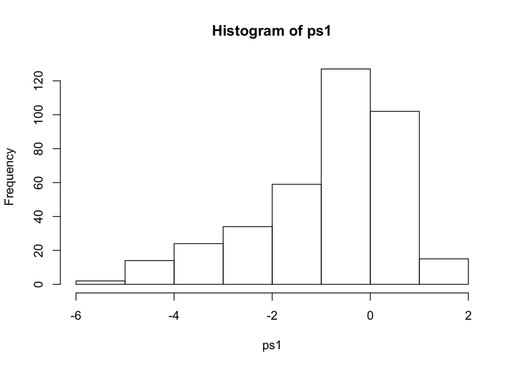

```r
hist(ps1)
```

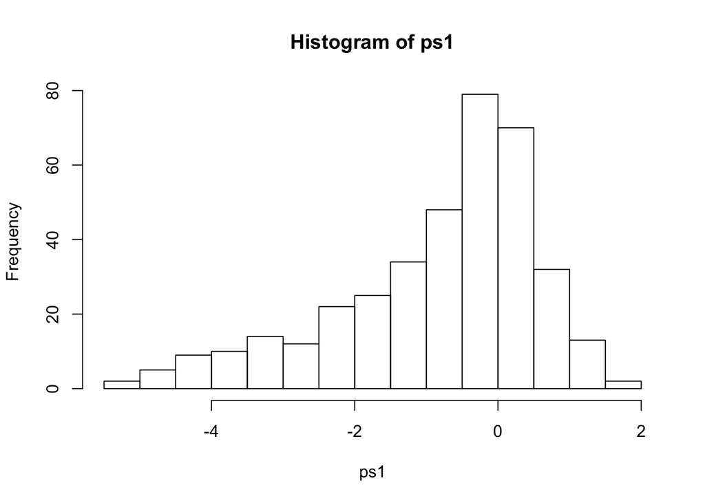

```r
?hist
hist(ps1, breaks = 20)
```

##### Let’s change this to a density histogram

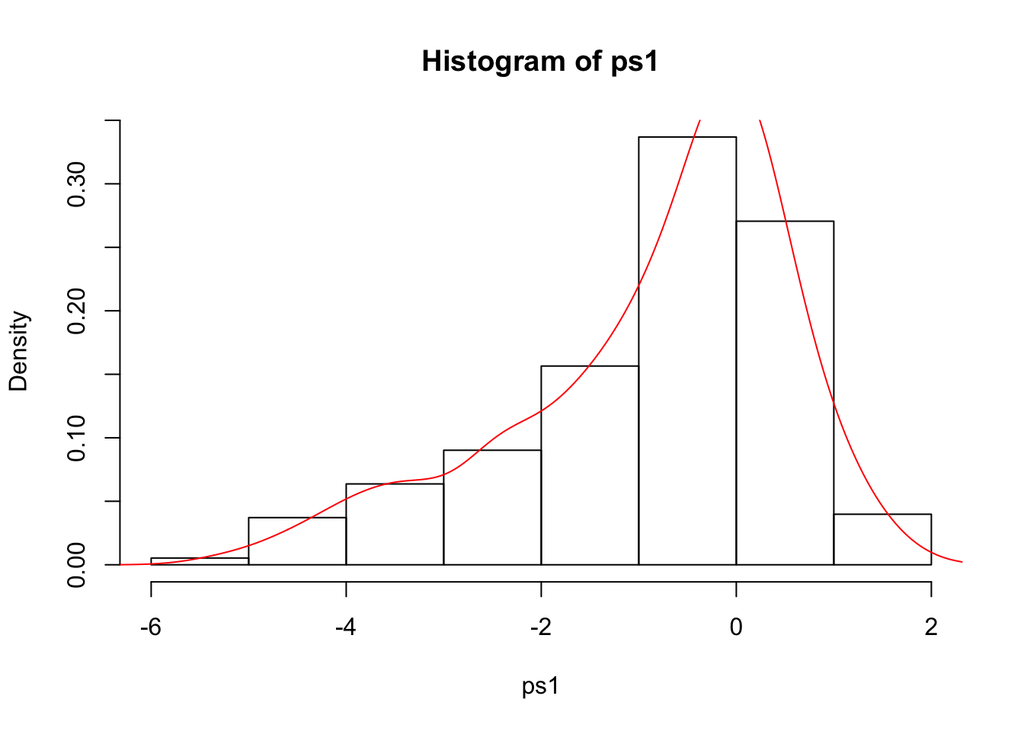

```r
hist(ps1, freq=F)

# And add the smoothed density function
lines((density(ps1)), col = "red")
```

##### Let’s make it prettier

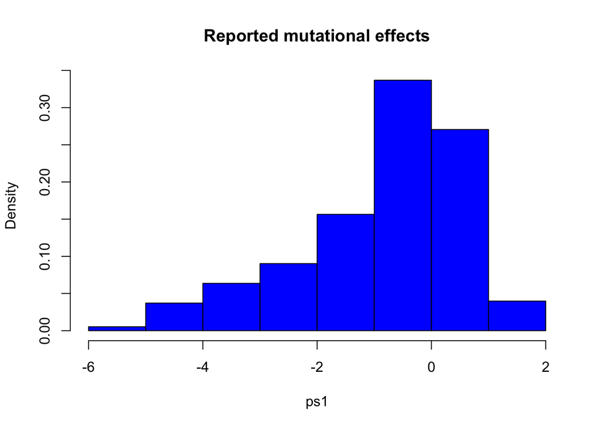

```r
hist(ps1, freq=F, main ="Reported mutational effects", col = "blue")
```

##### let’s make a plot with two histograms next to each other

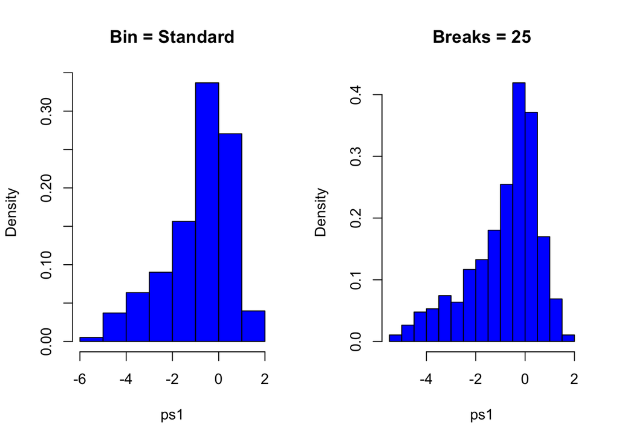

```r
par(mfrow=c(1,2))
hist(ps1, freq=F, main ="Bin = Standard", col = "blue")
hist(ps1, freq=F, main ="Breaks = 25", col = "blue", breaks = 25)
```

#### Boxplots

?boxplot

##### Let’s make a boxplot for reported scores for alanine and tryptophan

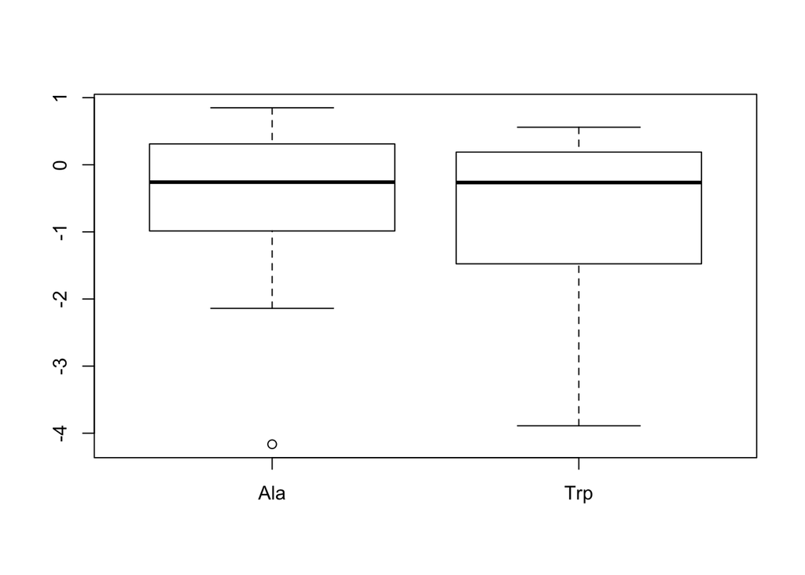

```r
boxplot(just_ala, just_trp, names = c("Ala", "Trp"))
```

```r
# Note that if we don't reset a graphical parameter, new plots use the old parameter values
```

#### Scatterplots

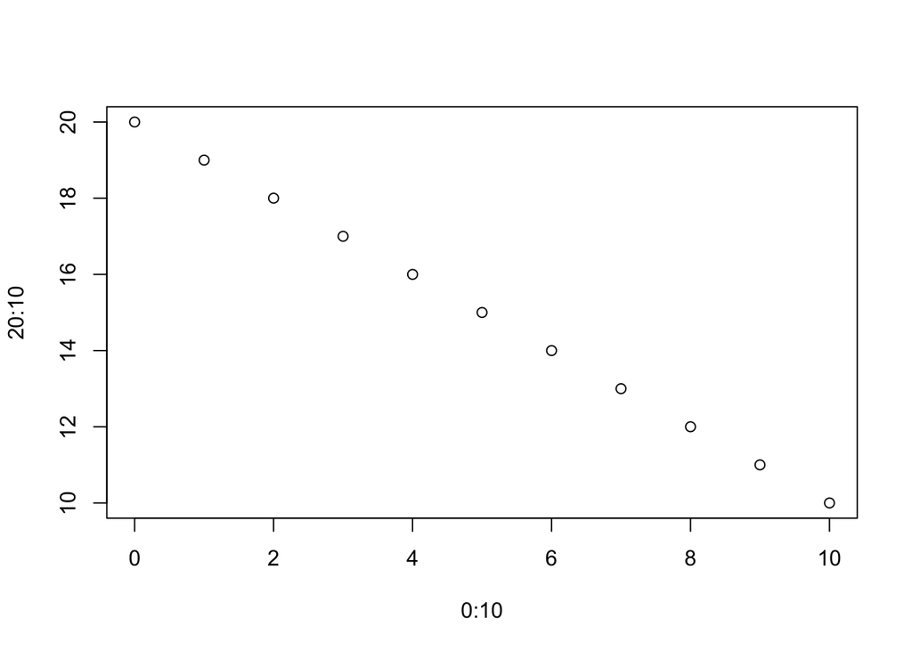

```r
plot(0:10, 20:10)
```

##### A little prettier please

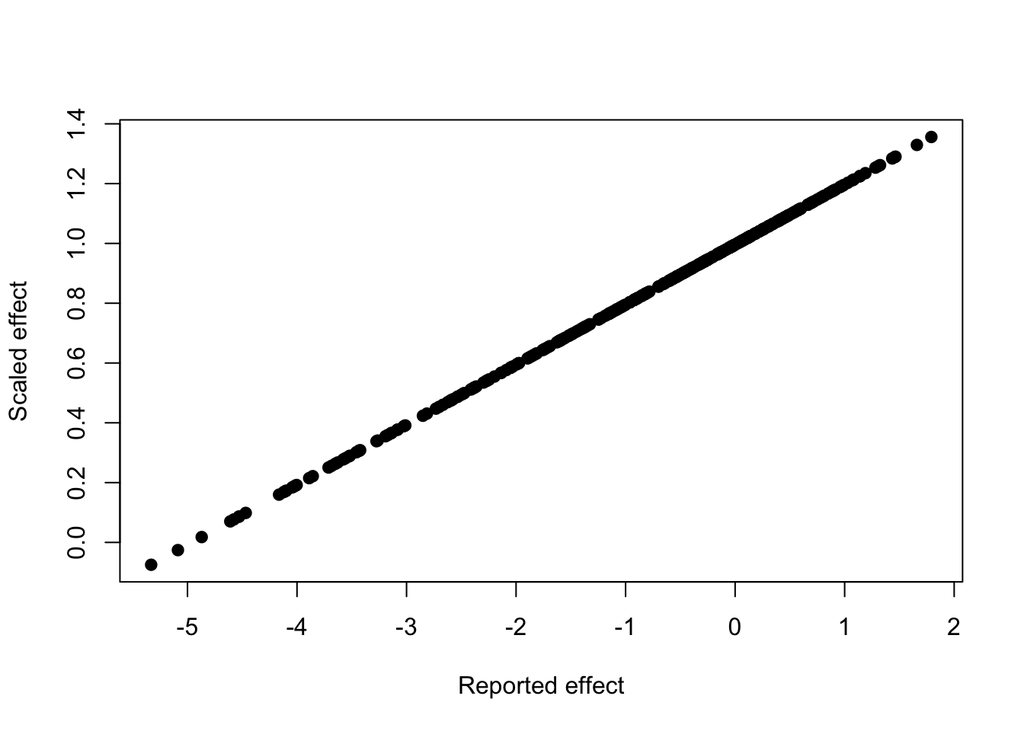

```r
plot(ww_data$reported_effect, ww_data$scaled_effect, pch = 19, xlab = "Reported effect", ylab = "Scaled effect")
```

##### We can add a line with the expected slope of 1

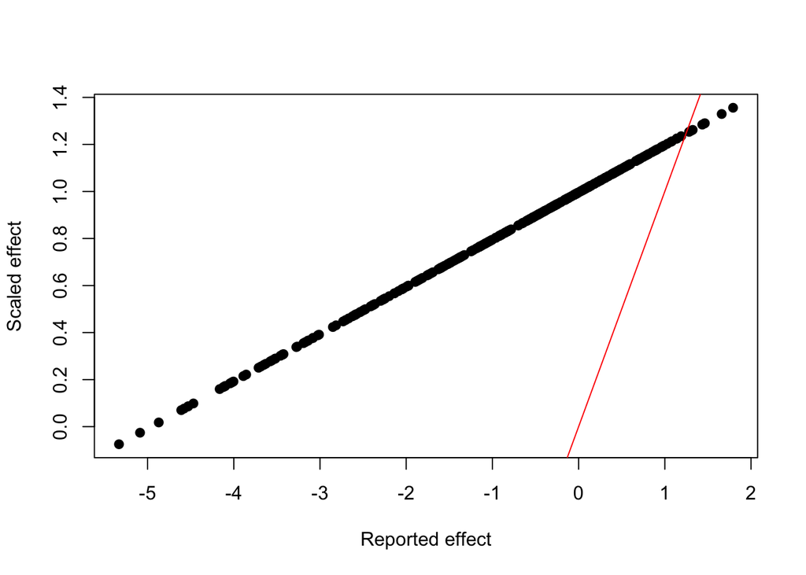

```r
plot(ww_data$reported_effect, ww_data$scaled_effect, pch = 19, xlab = "Reported effect", ylab = "Scaled effect")
abline(0,1, col = "red")
```

#### Graphical output

##### If you want to write the results directly to a file, you can use pdf(). If you make multiple plot() calls, you will get a multipage pdf.

```r
pdf(file="ww_reported_vs_scaled.pdf")
plot(ww_data$reported_effect, ww_data$scaled_effect, pch = 19, xlab = "Reported effect", ylab = "Scaled effect")
abline(0,1, col = "red")
dev.off()
```

## More advanced plotting - ggplot2

#### Let’s make a heatmap of reported effect of each substitution at every position. To do this, we’ll use the ggplot2 package. To install it, we use install.packages(). Then, we load the package using library().

```r
#install.packages("ggplot2")
library(ggplot2)
```

#### Find a useful cheat sheet for ggplot2 here: https://www.rstudio.com/wp-content/uploads/2015/03/ggplot2-cheatsheet.pdf

Ggplot is based around a “grammar” of graphics. A graphic is a mapping from data to aesthetic attributes (e.g. color, size, shape) of geometric objects (e.g. points, lines, bars, etc). The graphic could also contain a statistical transformations on a distinct coordinate system. Facetting can be used to create the same plot from multiple subsets of a dataset in a systematic way. The combination of these components makes up a graphic, and the structure of ggplot is based on this idea. In ggplot, all plots consist of

*data that you want to visualize* a set of aesthetic mappings that describe how variables in the data are visualized *layers, made up of geometric elements (e.g. geoms) that represent what you actually see on the plot* scales, that map data to values in aesthetic space (e.g. a color scale, number scale, etc) *faceting, which describes how to break up the data into sensible subsets (e.g. if you want scatter plot for two different conditions)* themes, which specify graphical details like background color, ticking, grids, etc

A typical ggplot call will look like this:

ggplot(some_data, aes(x, y, other_global_aesthetics)) + some_geom(local_aesthetics) + other_stuff()

Ggplot’s modular structure makes it very easy to plot the same data in different ways (e.g. histogram, density plot, violin plot, boxplot).

#### We use geom_tile() to make a heatmap

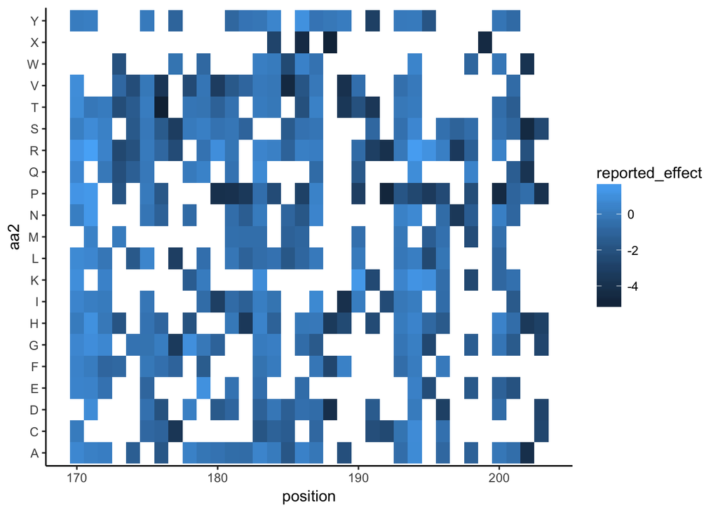

```r
ggplot(ww_data, aes(position, aa2)) + geom_tile(aes(fill = reported_effect)) + theme_classic()
```

#### Next, let’s make boxplots of the effect of every mutation at each position

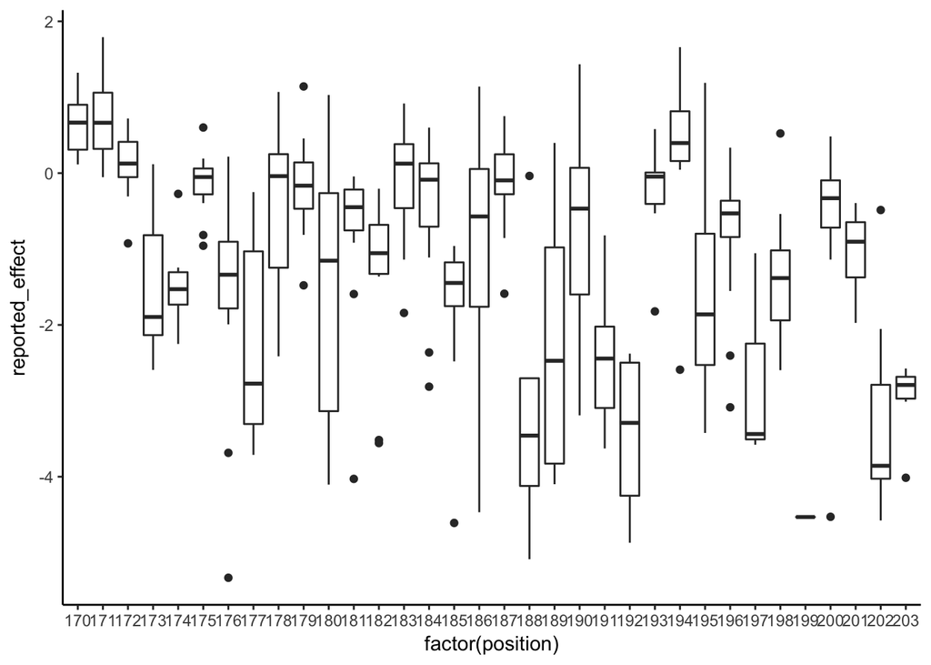

```r
ggplot(ww_data, aes(factor(position), reported_effect)) + geom_boxplot() + theme_classic()
```

#### Maybe we want to color each boxplot by the identity of the wild type amino acid there?

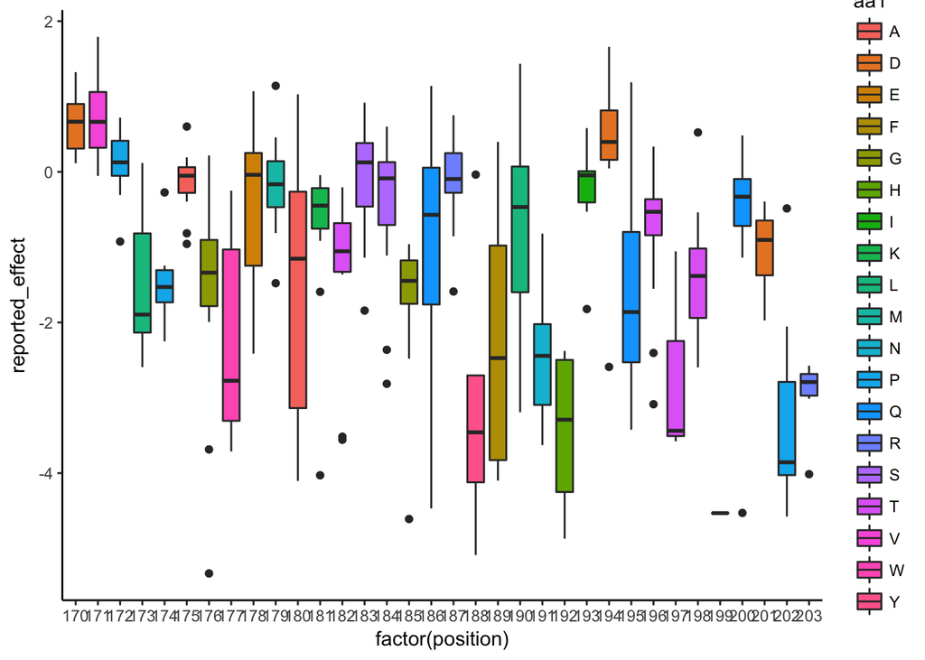

```r
ggplot(ww_data, aes(factor(position), reported_effect)) + geom_boxplot(aes(fill = aa1)) + theme_classic()
```

#### We could also visualize the positional reported effect distributions using violin plots

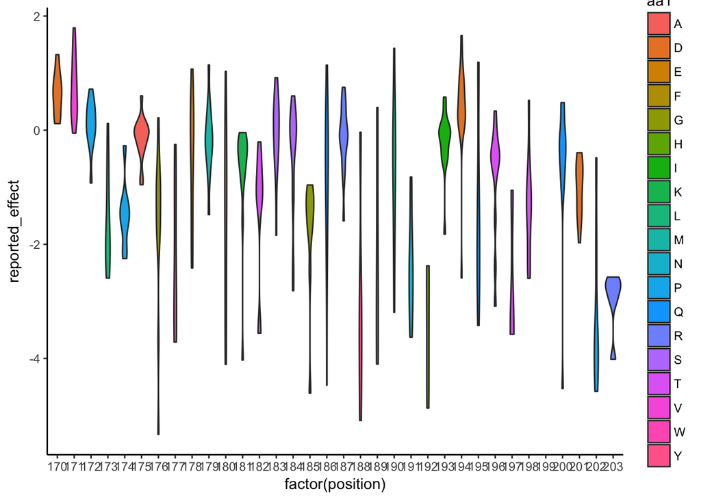

```r
ggplot(ww_data, aes(factor(position), reported_effect)) + geom_violin(aes(fill = aa1)) + theme_classic()
```